# Parametric vs Non-parametric

### **NOTES ON STATISTICS, PROBABILITY and MATHEMATICS**

### Parametric Versus Non-Parametric

From Introduction to Statistical Inference by JC Kiefer, where $\Omega$ apparently denotes a class of $\text{df}$ (df denoting distribution function), as opposed to sample space:

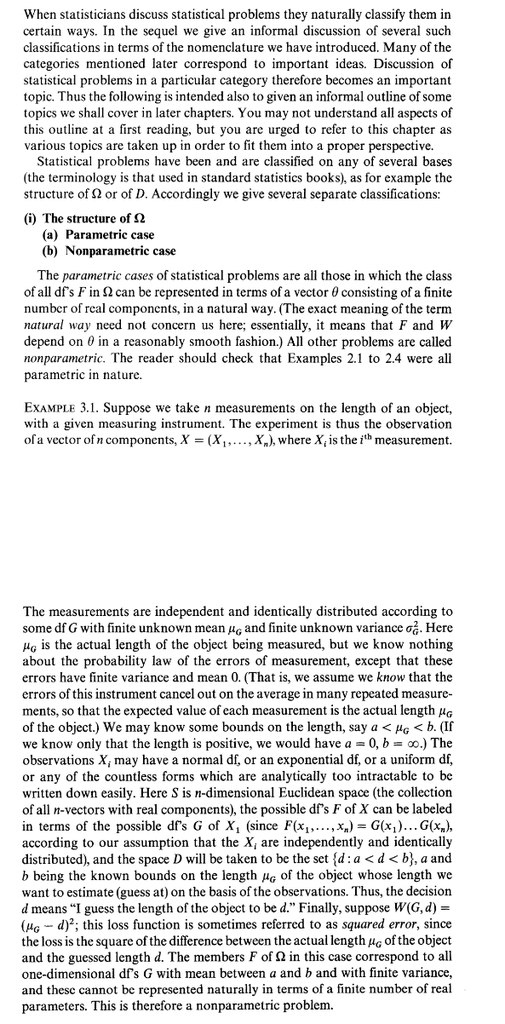

These are comments on [this post in CV](http://stats.stackexchange.com/q/18450/67822):

> “One of the Professor told me that ‘Chi-Square test’ has both behaviors (i.e., parametric and nonparametric as well). I did not understand at all, why ‘chi square test’ has both behaviors.”

It’s not the test that’s parametric, it’s the model that is. Chi-square distributions arise in both situations (in a natural way in the general linear model with Normal distributional assumptions, and as an approximation for a difference of log likelihoods–both of them parametric applications–and also as an approximation for the multinomial distributions that arise in many nonparametric applications), so there are many different tests sharing the name “chi-squared.” This is probably what suggested your professor’s comment.

> “Does your last comment mean that chi-square test for goodness-of-fit is nonparametric?”

In the sense described under “hypothesis testing” in here, yes it is nonparametric, because it applies to [almost] any distribution.

“Non-parametric” does not mean “no distributional assumptions.” On the contrary, the most well-known non-parametric tests all make distributional assumptions.

[Home Page](http://rinterested.github.io/statistics/index.html)

**NOTE: These are tentative notes on different topics for personal use - expect mistakes and misunderstandings.**